# Calibrating `dmin.grf` for GRF subgroup selection

A continuous-outcome (difference-in-means) calibration study, in sigma units, for the GRF tree and frontier selection arms

## 1 Purpose

`dmin.grf` is the harm-eligibility threshold for GRF subgroup selection: a candidate subgroup `S` is eligible only if its doubly-robust effect estimate (`mean(control) - mean(treated)`) exceeds `dmin.grf`. With `dmin.grf = 0`, *any* positive estimated harm qualifies, and – because selection maximises a noisy quantity over many candidate cuts – the null-arm false-discovery rate runs near 1 and *worsens* with `n`. A positive `dmin.grf` is the lever for controlling it.

There is no closed-form value. The closest theoretical framing is the constrained-policy-tree literature (Cai, Lu et al., *Stat Med* 2022, “CAPITAL”), which uses the same `policytree` machinery with a pre-specified threshold **delta** equal in role to `dmin.grf`, defined as the *minimum clinically meaningful mean contrast* in the selected subgroup – on the outcome’s natural scale (restricted mean survival time for survival). That literature treats the threshold as an a-priori clinical input and *varies it*, reporting sensitivity; it does not derive it from the null sampling distribution. So calibration, not derivation, is the defensible route, and that is what this study does.

**Why continuous outcomes first.** The threshold is fundamentally a difference in means on the outcome scale. The continuous / identity case is the most transparent: the causal-forest doubly-robust score is an estimate of the per-subject treatment effect *in outcome units*, so a `dmin.grf` reported in **units of the residual SD (sigma)** is a standardized mean contrast – a Cohen’s-d-like quantity that translates *approximately* to the other scales (RMST difference for survival, risk difference for binary, rate difference for count), since each is a mean contrast on its own scale. The continuous study therefore gives a starting region and – more durably – the *scaling behaviour* of the false-discovery-controlling floor with `n` and with the candidate-pool size. It is a start, not a transplantable constant; see the caveats at the end.

> **Scale note.** For survival, `dmin.grf` is on the RMST (time-unit) scale, not the hazard-ratio scale. The continuous study expresses `dmin.grf` in sigma units; mapping to a survival study requires multiplying by the RMST-difference SD, and the bridge is approximate (good for small effects / locally-linear links, weaker for large effects or skewed baselines).

```r
library(forestsearch)
library(data.table)
library(ggplot2)
library(grf)
library(policytree)
library(future)
library(foreach)
library(doFuture)

# Graphics utilities (shared OC-bubble vocabulary), resolved whether rendering
# from the package root or from within quarto/<subdir>/.
.util_dir <- "../_utils"
if (!dir.exists(.util_dir)) .util_dir <- file.path("..", "..", "_utils")

registerDoFuture()

CONFIG <- list(
  # Monte Carlo
  nsims      = 500L,                       # replications per (regime, n, dmin) cell
  base_seed  = 20260601L,
  d          = 5L,                         # covariate dimension
  sigma      = 1.0,                        # residual SD; dmin.grf reported in these units

  # Design grids
  n_levels   = c(500L, 1000L, 2000L),      # sample sizes (exposes 1/sqrt(n) scaling)
  dmin_grid  = seq(0.0, 0.8, by = 0.1),    # dmin.grf in sigma units
  delta_true = 1.0,                        # planted standardized harm in S (signal regime)
  run_signal = TRUE,                       # FALSE = null arm only (FDR); skips the
                                           # signal/power regime, ~halving runtime
                                           # (the signal regime is the costlier half)

  # GRF selection settings
  grf_selection_arms = c("tree", "frontier"),
  grf_depth  = 1L,                         # candidate depth (1 = single split / threshold)
  sg_focus   = "effMaxSG",
  eff_neighbor = 0.10,
  frac_tau   = 0.80,                       # unused for continuous; kept for parity
  n_min      = 60L,

  # Parallel
  workers    = floor(0.9*max(1L, future::availableCores() - 1L)),
  plan       = "multisession"
)

# True harm subgroup: S = {x1 > 0}, true |S|/n ~ 0.5.
S_fun     <- function(X) X[, 1] > 0
TRUE_FRAC <- 0.5
```

## 2 Data-generating model

Continuous outcome, `Y = 0.3 * x1 + A * C(X) + eps`, with `eps ~ N(0, sigma^2)`. In the **signal** regime the treatment *lowers* `Y` by `delta_true * sigma` on `S = {x1 > 0}` (harm = treated do worse); outside `S` there is no effect. In the **null** regime `C(X) = 0` everywhere. We run with `adverse_outcome = FALSE` (higher `Y` = better), so the GRF harm side – the most-negative-CATE region – is exactly `S`.

```r
gen_data <- function(n, d, sigma, delta, S_fun = NULL) {
  X <- matrix(runif(n * d, -1, 1), n, d)
  colnames(X) <- paste0("x", seq_len(d))
  A <- rbinom(n, 1, 0.5)
  inS <- if (is.null(S_fun)) rep(FALSE, n) else S_fun(X)
  # delta is in sigma units; harm = treated lower Y by delta*sigma on S.
  C <- ifelse(inS, -delta * sigma, 0)
  Y <- 0.3 * X[, 1] + A * C + rnorm(n, 0, sigma)
  data.table(Y = Y, trt = A, as.data.table(X), id = seq_len(n),
             inS = inS)
}
```

## 3 One run: fit a GRF arm at a given `dmin.grf`, score recovery

```r
# Returns one row: found + membership-based recovery vs the true mask.
fit_and_score <- function(dt, covs, sel, dmin, cfg) {
  df <- as.data.frame(dt[, c("Y", "trt", covs, "id"), with = FALSE])
  fs <- tryCatch(
    suppressWarnings(forestsearch(
      df.analysis      = df,
      outcome.name     = "Y",
      treat.name       = "trt",
      id.name          = "id",
      confounders.name = covs,
      df.predict       = df,
      outcome_type     = "continuous",
      effect_measure   = "MD",
      adverse_outcome  = FALSE,
      subgroup_method  = "grf",
      grf_selection    = sel,
      sg_focus         = cfg$sg_focus,
      effect_neighborhood = cfg$eff_neighbor,
      grf_depth        = cfg$grf_depth,
      dmin.grf         = dmin,
      n.min            = cfg$n_min,
      is.RCT           = TRUE,
      seedit           = 8316951L,
      details          = FALSE,
      quiet            = TRUE,
      parallel_args    = list(plan = "sequential", workers = 1,
                              show_message = FALSE)
    )),
    error = function(e) NULL)

  truth <- dt$inS
  found <- !is.null(fs) && !is.null(fs$sg.harm) &&
           length(fs$sg.harm) > 0 && any(fs$df.est$treat.recommend == 0)
  if (!found) {
    return(data.table(found = FALSE, sens = NA_real_, spec = NA_real_,
                      ppv = NA_real_, npv = NA_real_, frac = NA_real_,
                      cov_hit = NA))
  }
  mask <- fs$df.est$treat.recommend == 0
  tp <- sum(mask & truth); fp <- sum(mask & !truth)
  fn <- sum(!mask & truth); tn <- sum(!mask & !truth)
  safe <- function(a, b) if (b > 0) a / b else NA_real_
  # cov_hit: did the discovered rule use exactly {x1}?  (depth-1 single factor)
  vars <- unique(unlist(regmatches(fs$sg.harm,
            gregexpr("x[0-9]+", fs$sg.harm))))
  cov_hit <- length(vars) == 1L && identical(vars, "x1")
  data.table(found = TRUE,
             sens = safe(tp, tp + fn), spec = safe(tn, tn + fp),
             ppv  = safe(tp, tp + fp), npv  = safe(tn, tn + fn),
             frac = mean(mask), cov_hit = cov_hit)
}
```

## 4 Sweep: regimes x n x dmin.grf x selection arm

The sweep runs live on every render: `nsims x |n| x |dmin| x 2 arms` forest fits per regime, in parallel via `doFuture`. All tunable knobs live in the `CONFIG` list in the `setup` chunk at the top of this document – adjust `nsims`, `n_levels`, `dmin_grid`, `delta_true`, and the parallel `workers`/`plan` there.

```r
future::plan(CONFIG$plan, workers = CONFIG$workers)
on.exit({ future::plan("sequential"); gc(verbose = FALSE) }, add = TRUE)

covs    <- paste0("x", seq_len(CONFIG$d))
regimes <- if (isTRUE(CONFIG$run_signal)) c("null", "signal") else "null"

# Run each regime separately so wall-clock time can be attributed per regime
# (the signal/power regime is the costlier half).  timings collects elapsed
# seconds; res accumulates the rows.
.t_start <- proc.time()[["elapsed"]]
res_list <- vector("list", length(regimes))
timings  <- data.table(regime = regimes, wall_sec = NA_real_, n_fits = NA_integer_)

for (rg in regimes) {
  grid <- CJ(n   = CONFIG$n_levels,
             dmin = CONFIG$dmin_grid,
             sel  = CONFIG$grf_selection_arms,
             sim  = seq_len(CONFIG$nsims))
  .t0 <- proc.time()[["elapsed"]]
  rr <- foreach(i = seq_len(nrow(grid)), .combine = rbind,
                .options.future = list(seed = TRUE)) %dofuture% {
    row <- grid[i]
    set.seed(CONFIG$base_seed + row$sim +
             1000L * match(rg, c("null", "signal")) +
             7L * match(row$n, CONFIG$n_levels))
    delta <- if (rg == "signal") CONFIG$delta_true else 0
    Sf    <- if (rg == "signal") S_fun else NULL
    dt    <- gen_data(row$n, CONFIG$d, CONFIG$sigma, delta, Sf)
    out   <- fit_and_score(dt, covs, row$sel, row$dmin, CONFIG)
    cbind(data.table(regime = rg), row[, .(n, dmin, sel, sim)], out)
  }
  .elapsed <- proc.time()[["elapsed"]] - .t0
  timings[regime == rg, `:=`(wall_sec = .elapsed, n_fits = nrow(grid))]
  res_list[[match(rg, regimes)]] <- as.data.table(rr)
}
res            <- rbindlist(res_list)
total_wall_sec <- proc.time()[["elapsed"]] - .t_start
future::plan("sequential"); gc(verbose = FALSE)
```

```
          used  (Mb) gc trigger  (Mb) max used  (Mb)
Ncells 2562178 136.9    6035583 322.4  6035583 322.4
Vcells 5890903  45.0   88649793 676.4 95311022 727.2
```

## 5 Wall-clock timing

```r
n_workers <- tryCatch(future::nbrOfWorkers(), error = function(e) NA_integer_)
timing_tbl <- copy(timings)
timing_tbl[, `:=`(
  wall_min  = round(wall_sec / 60, 2),
  sec_per_fit = round(wall_sec / n_fits, 3))]
timing_tbl <- rbind(
  timing_tbl[, .(regime, n_fits, wall_min, sec_per_fit)],
  data.table(regime = "TOTAL", n_fits = sum(timing_tbl$n_fits),
             wall_min = round(total_wall_sec / 60, 2),
             sec_per_fit = round(total_wall_sec / sum(timing_tbl$n_fits), 3)))
knitr::kable(
  timing_tbl,
  col.names = c("regime", "# fits", "wall (min)", "sec / fit"),
  caption = sprintf(
    "Sweep wall-clock time (workers = %s, plan = %s, nsims = %d). 'signal' is the power regime; set run_signal = FALSE to skip it.",
    n_workers, CONFIG$plan, CONFIG$nsims))
```

Sweep wall-clock time (workers = 1, plan = multisession, nsims = 500). ‘signal’ is the power regime; set run_signal = FALSE to skip it.

| regime | # fits | wall (min) | sec / fit |
| --- | --- | --- | --- |
| null | 27000 | 86.49 | 0.192 |
| signal | 27000 | 86.48 | 0.192 |
| TOTAL | 54000 | 172.97 | 0.192 |

## 7 Detailed results

The full per-cell aggregate over the `nsims` replications: for the `null` regime, `fdr` is the false-discovery rate (any discovery is a false positive); for the `signal` regime, `power` is the detection rate and the remaining columns describe the recovered subgroup (`cov_hit`, `sens`, `spec`, `ppv`, `npv`, and `frac` = |S-hat|/n). One row per (regime, n, dmin.grf, arm). This table always renders; the plots that follow are summaries of it.

```r
agg <- res[, .(
  found_rate = mean(found),                       # fdr (null) / power (signal)
  cov_hit    = mean(cov_hit[found], na.rm = TRUE),
  sens       = mean(sens, na.rm = TRUE),
  spec       = mean(spec, na.rm = TRUE),
  ppv        = mean(ppv,  na.rm = TRUE),
  npv        = mean(npv,  na.rm = TRUE),
  frac       = mean(frac, na.rm = TRUE)
), by = .(regime, n, dmin, sel)][order(regime, sel, n, dmin)]
# fdr and power are the same statistic (found_rate) in their respective
# regimes; expose both names for readability downstream.
agg[, fdr   := fifelse(regime == "null",   found_rate, NA_real_)]
agg[, power := fifelse(regime == "signal", found_rate, NA_real_)]

knitr::kable(
  agg[, .(regime, n, dmin, sel,
          found_rate = round(found_rate, 3),
          cov_hit = round(cov_hit, 3), sens = round(sens, 3),
          spec = round(spec, 3), ppv = round(ppv, 3), npv = round(npv, 3),
          frac = round(frac, 3))],
  col.names = c("regime", "n", "dmin", "arm", "found/FDR/power",
                "cov-hit", "sens", "spec", "ppv", "npv", "|S-hat|/n"),
  caption = sprintf(
    "Per-cell operating characteristics over %d replications (nsims). 'found/FDR/power' = mean found (= FDR under null, = power under signal).",
    CONFIG$nsims))
```

Per-cell operating characteristics over 500 replications (nsims). ‘found/FDR/power’ = mean found (= FDR under null, = power under signal).

| regime | n | dmin | arm | found/FDR/power | cov-hit | sens | spec | ppv | npv | \|S-hat\|/n |
| --- | --- | --- | --- | --- | --- | --- | --- | --- | --- | --- |
| null | 500 | 0.0 | frontier | 0.992 | 0.244 | NaN | 0.737 | 0.000 | 1.000 | 0.263 |
| null | 500 | 0.1 | frontier | 0.946 | 0.243 | NaN | 0.741 | 0.000 | 1.000 | 0.259 |
| null | 500 | 0.2 | frontier | 0.764 | 0.241 | NaN | 0.747 | 0.000 | 1.000 | 0.253 |
| null | 500 | 0.3 | frontier | 0.458 | 0.258 | NaN | 0.763 | 0.000 | 1.000 | 0.237 |
| null | 500 | 0.4 | frontier | 0.180 | 0.233 | NaN | 0.772 | 0.000 | 1.000 | 0.228 |
| null | 500 | 0.5 | frontier | 0.044 | 0.227 | NaN | 0.795 | 0.000 | 1.000 | 0.205 |
| null | 500 | 0.6 | frontier | 0.012 | 0.333 | NaN | 0.800 | 0.000 | 1.000 | 0.200 |
| null | 500 | 0.7 | frontier | 0.000 | NaN | NaN | NaN | NaN | NaN | NaN |
| null | 500 | 0.8 | frontier | 0.000 | NaN | NaN | NaN | NaN | NaN | NaN |
| null | 1000 | 0.0 | frontier | 1.000 | 0.224 | NaN | 0.858 | 0.000 | 1.000 | 0.142 |
| null | 1000 | 0.1 | frontier | 0.960 | 0.225 | NaN | 0.860 | 0.000 | 1.000 | 0.140 |
| null | 1000 | 0.2 | frontier | 0.814 | 0.224 | NaN | 0.868 | 0.000 | 1.000 | 0.132 |
| null | 1000 | 0.3 | frontier | 0.462 | 0.221 | NaN | 0.882 | 0.000 | 1.000 | 0.118 |
| null | 1000 | 0.4 | frontier | 0.180 | 0.233 | NaN | 0.890 | 0.000 | 1.000 | 0.110 |
| null | 1000 | 0.5 | frontier | 0.048 | 0.250 | NaN | 0.900 | 0.000 | 1.000 | 0.100 |
| null | 1000 | 0.6 | frontier | 0.004 | 0.000 | NaN | 0.900 | 0.000 | 1.000 | 0.100 |
| null | 1000 | 0.7 | frontier | 0.002 | 0.000 | NaN | 0.900 | 0.000 | 1.000 | 0.100 |
| null | 1000 | 0.8 | frontier | 0.000 | NaN | NaN | NaN | NaN | NaN | NaN |
| null | 2000 | 0.0 | frontier | 0.998 | 0.210 | NaN | 0.856 | 0.000 | 1.000 | 0.144 |
| null | 2000 | 0.1 | frontier | 0.910 | 0.209 | NaN | 0.860 | 0.000 | 1.000 | 0.140 |
| null | 2000 | 0.2 | frontier | 0.556 | 0.191 | NaN | 0.878 | 0.000 | 1.000 | 0.122 |
| null | 2000 | 0.3 | frontier | 0.150 | 0.173 | NaN | 0.887 | 0.000 | 1.000 | 0.113 |
| null | 2000 | 0.4 | frontier | 0.020 | 0.300 | NaN | 0.900 | 0.000 | 1.000 | 0.100 |
| null | 2000 | 0.5 | frontier | 0.004 | 0.500 | NaN | 0.900 | 0.000 | 1.000 | 0.100 |
| null | 2000 | 0.6 | frontier | 0.000 | NaN | NaN | NaN | NaN | NaN | NaN |
| null | 2000 | 0.7 | frontier | 0.000 | NaN | NaN | NaN | NaN | NaN | NaN |
| null | 2000 | 0.8 | frontier | 0.000 | NaN | NaN | NaN | NaN | NaN | NaN |
| null | 500 | 0.0 | tree | 0.950 | 0.204 | NaN | 0.482 | 0.000 | 1.000 | 0.518 |
| null | 500 | 0.1 | tree | 0.924 | 0.201 | NaN | 0.486 | 0.000 | 1.000 | 0.514 |
| null | 500 | 0.2 | tree | 0.578 | 0.201 | NaN | 0.550 | 0.000 | 1.000 | 0.450 |

[output cut: 78 more lines]

## 8 Operating-characteristic curves

The two curves that define the calibration: null-arm **false-discovery rate** vs `dmin.grf` (how high the floor must be to control false discovery) and signal-arm **power** and **size accuracy** vs `dmin.grf` (the cost). The smallest `dmin.grf` bringing the null FDR to a chosen target – with acceptable signal-arm power – is the calibrated value, *for that `n` and candidate pool*.

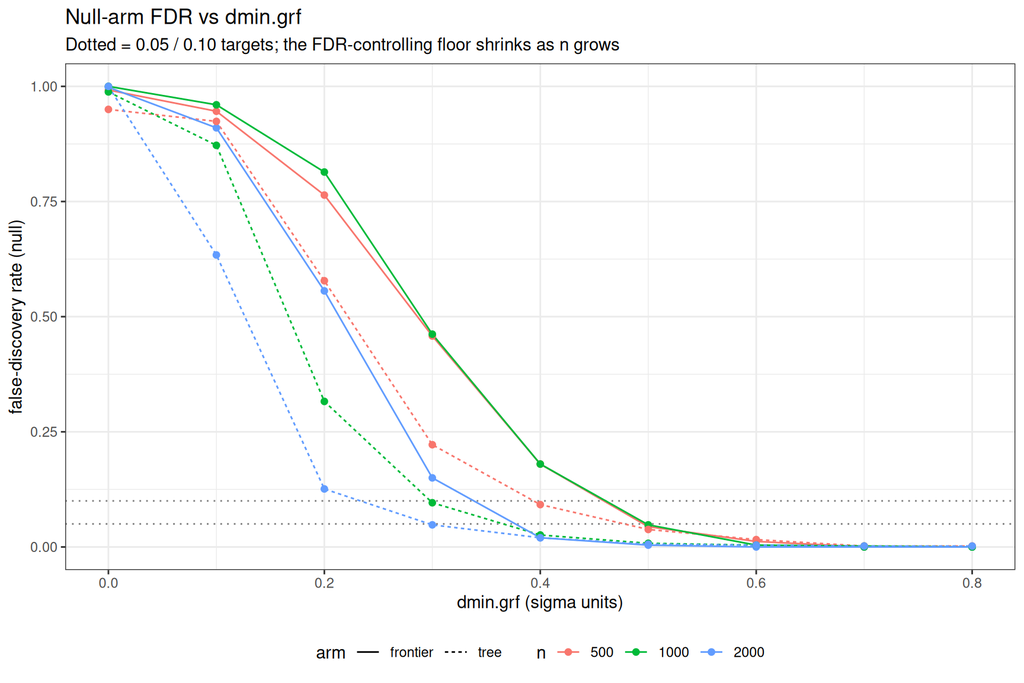

```r
# Null-arm FDR vs dmin, by n and arm
ggplot(agg[regime == "null"],
       aes(x = dmin, y = fdr, colour = factor(n), linetype = sel)) +
  geom_hline(yintercept = c(0.05, 0.10), linetype = "dotted", colour = "grey50") +
  geom_line() + geom_point(size = 1.6) +
  scale_y_continuous(limits = c(0, 1)) +
  labs(x = "dmin.grf (sigma units)", y = "false-discovery rate (null)",
       colour = "n", linetype = "arm",
       title = "Null-arm FDR vs dmin.grf",
       subtitle = "Dotted = 0.05 / 0.10 targets; the FDR-controlling floor shrinks as n grows") +
  theme_bw() + theme(legend.position = "bottom")
```

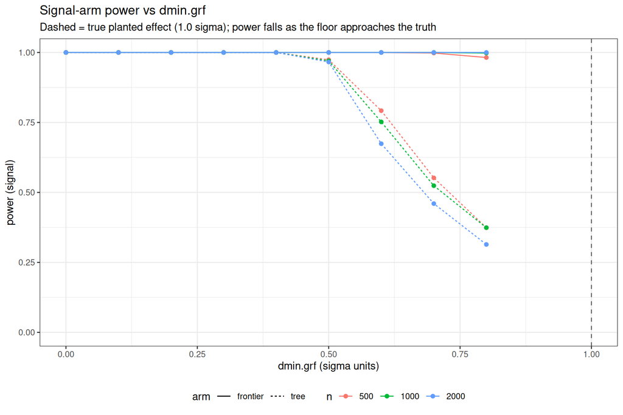

```r
# Signal-arm power vs dmin, by n and arm
ggplot(agg[regime == "signal"],
       aes(x = dmin, y = power, colour = factor(n), linetype = sel)) +
  geom_vline(xintercept = CONFIG$delta_true, linetype = "dashed", colour = "grey40") +
  geom_line() + geom_point(size = 1.6) +
  scale_y_continuous(limits = c(0, 1)) +
  labs(x = "dmin.grf (sigma units)", y = "power (signal)",
       colour = "n", linetype = "arm",
       title = "Signal-arm power vs dmin.grf",
       subtitle = sprintf("Dashed = true planted effect (%.1f sigma); power falls as the floor approaches the truth",
                          CONFIG$delta_true)) +
  theme_bw() + theme(legend.position = "bottom")
```

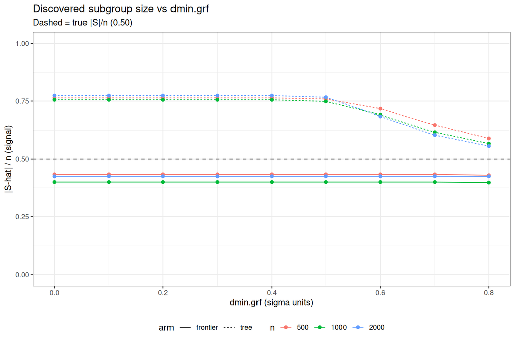

```r
# Signal-arm size accuracy: |S-hat|/n vs dmin, against the true fraction
ggplot(agg[regime == "signal"],
       aes(x = dmin, y = frac, colour = factor(n), linetype = sel)) +
  geom_hline(yintercept = TRUE_FRAC, linetype = "dashed", colour = "grey40") +
  geom_line() + geom_point(size = 1.6) +
  scale_y_continuous(limits = c(0, 1)) +
  labs(x = "dmin.grf (sigma units)", y = "|S-hat| / n (signal)",
       colour = "n", linetype = "arm",
       title = "Discovered subgroup size vs dmin.grf",
       subtitle = sprintf("Dashed = true |S|/n (%.2f)", TRUE_FRAC)) +
  theme_bw() + theme(legend.position = "bottom")
```

## 9 Calibrated floor

For each `n` and arm, the smallest `dmin.grf` on the grid that brings the null-arm FDR at or below the target, with the signal-arm power it costs there.

```r
target_fdr <- 0.10
null_agg <- agg[regime == "null"]
calib <- null_agg[fdr <= target_fdr][order(dmin),
                   .(dmin_star = dmin[1]), by = .(n, sel)]
if (isTRUE(CONFIG$run_signal)) {
  sig_agg <- agg[regime == "signal"]
  calib <- merge(calib, sig_agg[, .(n, sel, dmin, power)],
                 by.x = c("n", "sel", "dmin_star"),
                 by.y = c("n", "sel", "dmin"), all.x = TRUE)
  setnames(calib, "power", "power_at_dmin_star")
} else {
  calib[, power_at_dmin_star := NA_real_]  # signal regime not run
}
calib[order(sel, n)]
```

| n | sel | dmin_star | power_at_dmin_star |
| --- | --- | --- | --- |
| 500 | frontier | 0.5 | 1 |
| 1000 | frontier | 0.5 | 1 |
| 2000 | frontier | 0.4 | 1 |
| 500 | tree | 0.4 | 1 |
| 1000 | tree | 0.3 | 1 |
| 2000 | tree | 0.3 | 1 |